# Lecture 8-2: Optimization II

# Agenda

- Basics of optimization
- Gradient descent method

# Examples of Optimization Problems

- Minimize mean-squared error of regression. (Gauss, c. 1800)
- Maximize likelihood of distribution. (Fisher, c. 1918)

# Optimization Problems

Given an **objective function** $f: \mathcal{D} \mapsto R$, find
$$\DeclareMathOperator*{\argmax}{argmax}
\DeclareMathOperator*{\argmin}{argmin}
\theta^* = \argmin_{\theta}\{f(\theta)\}.$$

Basics: maximizing $f$ is minimizing $-f$:
$$\argmax_{\theta}\{f(\theta)\}= \argmin_{\theta}\{-f(\theta)\}.$$

If $h$ is strictly increasing (e.g., $\log$), then
$$\argmin_{\theta}\{f(\theta)\} = \argmin_{\theta}\{h(f(\theta))\}.$$

## Considerations

- Approximation: How close can we get to $\theta^*$, and/or $f(\theta^*)$?
- Time complexity: How many computer steps does that take?
- Varies with precision of approximation, niceness of $f$, size of $\mathcal{D}$, size of data, method…
- Most optimization algorithms use **successive approximation**, so distinguish number of iterations from cost of each iteration.

## Calculus

Suppose $x$ is one dimensional and $f$ is smooth (differentiable). If $x^*$ is an *interior* minimum/maximum/extremum point:
$${\left. \frac{df}{dx} \right|}_{x=x^*} = 0.$$
If $x^*$ a minimum,
$${\left. \frac{d^2f}{dx^2}\right|}_{x=x^*} > 0.$$

This all carries over to multiple dimensions: At an *interior extremum*,
$$\nabla f(\theta^*) = 0.$$

At an **interior minimum**,
$$\nabla^2 f(\theta^*) \geq 0,$$
meaning for any vector $v$,
$$v^T \mathbf{H} v \geq 0$$
(positive semi-definite), where $\mathbf{H}$ is the *Hessian*, then $\theta^*$ is a *local minimum*.

## Gradients and Changes to f

$$f^{\prime}(x_0) = {\left. \frac{df}{dx}\right|}_{x=x_0} = \lim_{x\rightarrow x_0}{\frac{f(x)-f(x_0)}{x-x_0}}.$$

$$f(x) \approx f(x_0) +(x-x_0)f^{\prime}(x_0).$$

Locally, the function looks linear; to minimize a linear function, move down the slope.

Multivariate version:

$$f(\theta) \approx f(\theta_0) + (\theta-\theta_0) \cdot \nabla f(\theta_0)$$

where $\nabla f(\theta_0)$ points in the direction of fastest ascent at $\theta_0$.

# Gradient Descent - Algorithm

1. Start with an initial guess for theta, call it theta0, step-size eta.
2. Repeat:
3. Start with an initial guess for theta, call it theta(0), step-size eta.
4. For every i >= 0, do:
- Find the gradient of f at theta(i)
- If the gradient of f at theta(i) is “close enough” to the zero vector stop and return theta(i) as approximate theta*.
- Else, set theta(i+1) = theta(i) - eta * ( gradient of f at theta(i) ) and repeat.

# Pros and Cons of Gradient Descent

- Pros:
  - Moves in direction of greatest immediate improvement.
  - If `eta` is small enough, gets to a local minimum eventually, and then stops.
- Cons:
  - “small enough” `eta` can be really, really small.
  - Slowness or zig-zagging if elements of the gradient of f are of very different sizes.

# Implementing the gradient descent method

At the heart of the gradient descent method lies the computation of the gradient.

We will use here the `numDeriv::grad()` function with its default method.

Exercise:

Write a `gradient_descent` function that finds the minimum of an arbitrary function.

1. What should be the inputs for the function?

Answer:

f - an arbitrary function theta0 - starting point (theta(0)) step_scale - coefficient of gradient in the descent (eta)

We define “small enough” to be when the absolute value of all the coordinates of the gradient is smaller than some `stopping_partial_deriv`.

In order to avoid infinite loops, it is recommended to add a maximal number of iterations, call it `max_iter`

In addition, it is advisable to allow passing more arguments to `f` via `...`

So, the function will look like:

```r
gradient_descent <- function(f, theta0, step_scale, stopping_deriv, max_iter, ...) {
    ""
    return("")
}
```

2. Write pseudo-code.
3. Write the function in R

Answer:

```r
gradient_descent <- function(f, theta0, step_scale, stopping_deriv, max_iter, ...) {
  theta <- theta0
  for (i in 1:max_iter) {
    gradient <- numDeriv::grad(f, theta, ...)
    if(all(abs(gradient) < stopping_deriv)) {
      break()
    }
    theta <- theta - step_scale * gradient
  }
  if (i == max_iter) {
    warning("Maximal number of iterations reached, convergence not assured")
  }
  fit <-
    list(
      argmin = theta,
      final_gradient = gradient,
      final_value = f(theta, ...),
      iterations = i,
      theta0 = theta0,
      step_scale = step_scale,
      stopping_deriv = stopping_deriv
      )
  return(fit)
}
```

4. Test it with functions for which you know the minimum (try random values for x0)

Answer:

```r
foo <- function(x) { sum(x^2) }

# Univariate:
gradient_descent(f = foo, theta0 = runif(1, -10, 10), step_scale = 0.001, 1e-6, 100000)
```

```
## $argmin
## [1] 4.997914e-07
##
## $final_gradient
## [1] 9.995827e-07
##
## $final_value
## [1] 2.497914e-13
##
## $iterations
## [1] 7941
##
## $theta0
## [1] 4.002127
##
## $step_scale
## [1] 0.001
##
## $stopping_deriv
## [1] 1e-06
```

```r
# Bivariate:
gradient_descent(f = foo, theta0 = runif(2, -10, 10), step_scale = 0.001, 1e-6, 100000)
```

```
## $argmin
## [1]  4.032307e-08 -4.990456e-07
##
## $final_gradient
## [1]  8.064613e-08 -9.980911e-07
##
## $final_value
## [1] 2.506724e-13
##
## $iterations
## [1] 8318
##
## $theta0
## [1]  0.686818 -8.500184
##
## $step_scale
## [1] 0.001
##
## $stopping_deriv
## [1] 1e-06
```

```r
# 15-variate:
gradient_descent(f = foo, theta0 = runif(15, -10, 10), step_scale = 0.001, 1e-6, 100000)
```

```
## $argmin
##  [1]  2.189154e-07 -3.917342e-07  3.130262e-07  2.909533e-07 -3.390497e-07
##  [6]  1.277047e-08 -4.401571e-07 -1.596164e-07  3.434836e-07 -8.229670e-08
## [11] -4.792909e-08 -1.720650e-07 -1.539317e-08  1.605585e-09 -4.996845e-07
##
## $final_gradient
##  [1]  4.378308e-07 -7.834684e-07  6.260525e-07  5.819065e-07 -6.780994e-07
##  [6]  2.554094e-08 -8.803143e-07 -3.192328e-07  6.869673e-07 -1.645934e-07
## [11] -9.585818e-08 -3.441300e-07 -3.078634e-08  3.211171e-09 -9.993690e-07
##
## $final_value
## [1] 1.124934e-12
##
## $iterations
## [1] 8397
##
## $theta0
##  [1]  4.36768822 -7.81568107  6.24534012  5.80495130 -6.76454703
##  [6]  0.25478994 -8.78179122 -3.18458464  6.85301038 -1.64194180
## [11] -0.95625683 -3.43295297 -0.30711664  0.03203381 -9.96945075
##
## $step_scale
## [1] 0.001
##
## $stopping_deriv
## [1] 1e-06
```

- Works equally well whether `f` is mean squared error of a regression, $\psi$ error of a regression, (negative log) likelihood, cost of a production plan, …

Exercise:

Use the gradient descent method to find the estimators for simple linear regression by minimizing the MSE.

The model is $y_i = \beta_0 + \beta_1 \cdot x_i + \epsilon_i$

Try your work on the MASS::cats data set, regressing Heart Weight on Body Weight. However, we’re using fewer observations and adding a fake new last observation that is an outlier:

```r
cats <- readRDS("fewer_cats.rds")
```

Tip: when you define the objective function (MSE), don’t use `x` as an argument because it will duplicate the `x` argument of `grad()`!

```r
MSE_regression <- function(b, Y, X) {
  return( mean ( ( Y - (b[1] + b[2] * X) )^2 ) )
}

b_MSE_GD <-
  gradient_descent(
    f = MSE_regression,
    theta0 = c(0, 0),
    step_scale = 0.001,
    stopping_deriv = 1e-4,
    max_iter = 200000,
    Y = cats$Hwt,
    X = cats$Bwt
    )
```

Compare your estimates to the least squares estimates obtained by `lm()`

```r
coef(lm(Hwt ~ Bwt, data = cats))
```

```
## (Intercept)         Bwt
##   -8.571513    7.188201
```

```r
b_MSE_GD$argmin
```

```
## [1] -8.569832  7.187605
```

Exercise:

Use the `psi` function from Lecture 8-1 for the regression (that is, use mean-psi-error instead of MSE as your objective function), set the additional parameter of psi to be `c = 1.2`.

This is a type of regression that is more robust to outliers, because psi(x) <= x^2

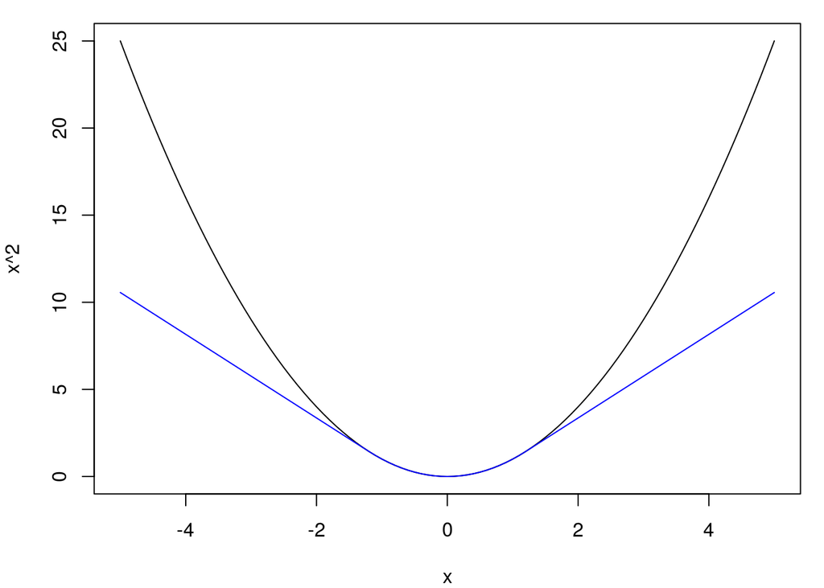

```r
psi <- function(x, c = 1) {
  return (
    ifelse(
      abs(x) > c,
      2 * c * abs(x) - c^2,
      x^2
    )
  )
}

par(mar = c(4, 4, 1, 1))
curve(x^2, from = -5, to = 5)
curve(psi(x, c = 1.2), from = -5, to = 5, add = TRUE, col = "blue")
```

The objective function and gradient descent for it:

```r
mean_psi_regression <- function(b, Y, X, c = 1) {
  return( mean ( psi( Y - ( b[1] + b[2] * X), c ) ) )
}

b_psi_GD <-
  gradient_descent(
    f = mean_psi_regression,
    theta0 = c(0, 0),
    step_scale = 0.001,
    stopping_deriv = 1e-4,
    max_iter = 250000,
    Y = cats$Hwt,
    X = cats$Bwt,
    c = 1.2
  )
```

Compare the results of the different methods for the original data set, and also compare the results to the OLS estimators (which are typically close to the MSE estimators computed with gradient descent) to see the effect of the outlier on the different estimates:

```r
coef(lm(Hwt ~ Bwt, data = cats))
```

```
## (Intercept)         Bwt
##   -8.571513    7.188201
```

```r
b_MSE_GD$argmin
```

```
## [1] -8.569832  7.187605
```

```r
b_psi_GD$argmin
```

```
## [1] -1.657665  4.382750
```

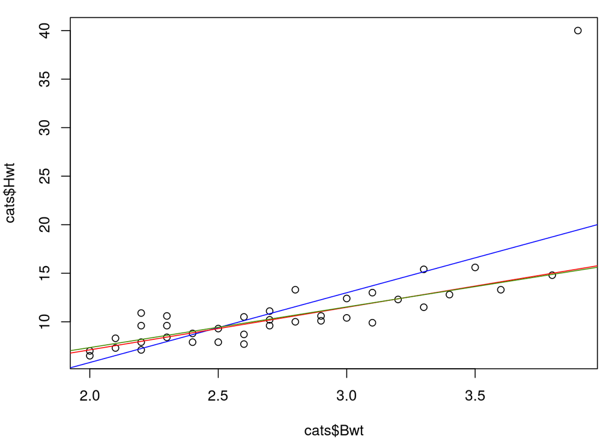

```r
par(mar = c(4, 4, 1, 1))
plot(cats$Bwt, cats$Hwt)
abline(a = b_MSE_GD$argmin[1], b = b_MSE_GD$argmin[2], col = "blue")
abline(a = b_psi_GD$argmin[1], b = b_psi_GD$argmin[2], col = "red")

# Compare to the lm coefficients without the outlier:
lm_no_outlier <- lm(Hwt ~ Bwt, data = cats[-nrow(cats) , ])
abline(lm_no_outlier, col = "chartreuse4")
```

And so you have written your own Robust Simple Linear Regression!

## Newton’s Method for Local Extremum

Taylor-expansion of $f$ *at the minimum* $\theta^*$
$$f(\theta^*) \approx f(\theta) + (\theta^*-\theta) \nabla f(\theta) +
\frac{1}{2}(\theta^*-\theta)^T \mathbf{H}(\theta) (\theta^*-\theta).$$
Take gradient, set to zero, solve for $\theta^*$:
$$\begin{eqnarray*}
0 & = & \nabla f(\theta) + \mathbf{H}(\theta) (\theta^*-\theta) \\
\theta^* & = & \theta - {\left(\mathbf{H}(\theta)\right)}^{-1} \nabla f(\theta).
\end{eqnarray*}$$
Works *exactly* if $f$ is quadratic and $\mathbf{H}^{-1}$ exists, etc. If $f$ isn’t quadratic, keep pretending it is until we get close to $\theta^*$, when it will be nearly true.

## Newton’s Method Algorithm

1. Start with guess for $\theta$.
2. Repeat:  
   - Find gradient $\nabla f(\theta)$ and Hessian $\mathbf{H}(\theta).$  
   - Set $\theta \leftarrow \theta - \mathbf{H}(\theta)^{-1} \nabla f(\theta).$
3. Return final $\theta$ as approximation to $\theta^*$ Like gradient descent, but with inverse Hessian giving the step-size: “this is about how far you can go with that gradient”.

## Advantages and Disadvantages of Newton’s Method

- Pros:
  - Step-sizes chosen adaptively through 2nd derivatives, much harder to get zig-zagging, over-shooting, etc.
  - Also guaranteed to need $O(\epsilon^{-2})$ steps to get within $\epsilon$ of optimum.
  - Only $O(\log\log{\epsilon^{-1}})$ for very nice functions.
  - Typically many fewer iterations than gradient descent.
- Cons:
  - Hopeless if $\mathbf{H}$ doesn’t exist or isn’t invertible.
  - Need to take $O(p^2)$ second derivatives *plus* $p$ first derivatives.
  - Need to solve $\mathbf{H} \theta_{\mathrm{new}} = \mathbf{H}\theta_{\mathrm{old}} - \nabla f(\theta_{\mathrm{old}})$ for $\theta_{\mathrm{new}}$ + inverting $\mathbf{H}$ is $O(p^3)$, but cleverness gives $O(p^2)$ for solving for $\theta_{\mathrm{new}}$.

## Getting Around the Hessian

We want to use the Hessian to improve convergence but do not want to keep computing the Hessian at each step:

Approaches:

1. Use knowledge of the system to get some approximation to the Hessian, use that instead of taking derivatives (“Fisher scoring”).
2. Use only diagonal entries ($p$ unmixed 2nd derivatives).
3. Use $\mathbf{H}(\theta)$ at initial guess, hope $\mathbf{H}$ changes *very* slowly with $\theta$.
4. Re-compute $\mathbf{H}(\theta)$ every $k$ steps, $k > 1$.
5. Fast, approximate updates to the Hessian at each step (BFGS).

## Curve-Fitting by Optimizing Revisited

We have data $(x_1, y_1), (x_2, y_2), \ldots (x_n, y_n).$ We also have possible curves $r(x)$ such as $r(x;\theta)$, $r(x) = x \cdot \theta$, $r(x) = \theta_1 x^{\theta_2}$, $r(x) = \sum_{j=1}^{q}{\theta_j b_j(x)}$ for fixed “basis” functions $b_j$.

Least-squares curve fitting:
$$\hat{\theta} = \argmin_{\theta}{\frac{1}{n}\sum_{i=1}^n{(y_i - r(x_i;\theta))^2}}.$$
“Robust” curve (changing weights) fitting:
$$\hat{\theta} = \argmin_{\theta}{\frac{1}{n}\sum_{i=1}^{n}{\psi(y_i - r(x_i;\theta))}}.$$

## Optimization in R: `optim()`

`optim(par, fn, gr, method, control, hessian)`

- `par`: initial parameter guess; mandatory.
- `fn`: function to be minimized; mandatory.
- `gr`: gradient function; only needed for some methods.
- `method`: defaults to a gradient-free method (“Nedler-Mead”), could be BFGS (quasi-Newton method).
- `control`: optional list of control settings + (maximum iterations, scaling, tolerance for convergence, etc.)
- `hessian`: should the final Hessian be returned? Default: FALSE.

Return contains the location (`$par`) and the value (`$val`) of the optimum, diagnostics, possibly `$hessian`.

```r
gmp <- read.table("gmp.dat")
gmp$pop <- gmp$gmp / gmp$pcgmp
library(numDeriv)
mse <- function(theta) {
  mean( (gmp$pcgmp - theta[1] * gmp$pop^theta[2]) ^2 )
}

grad.mse <- function(theta) {
  grad(func = mse, x = theta)
}

theta0 = c(5000, 0.15)
fit1 <- optim(theta0, mse, grad.mse, method = "BFGS", hessian = TRUE)
```

```r
fit1
```

```
## $par
## [1] 6493.2563738    0.1276921
##
## $value
## [1] 61853983
##
## $counts
## function gradient
##       63       11
##
## $convergence
## [1] 0
##
## $message
## NULL
##
## $hessian
##             [,1]         [,2]
## [1,] 5.25021e+01      4422070
## [2,] 4.42207e+06 375729087976
```

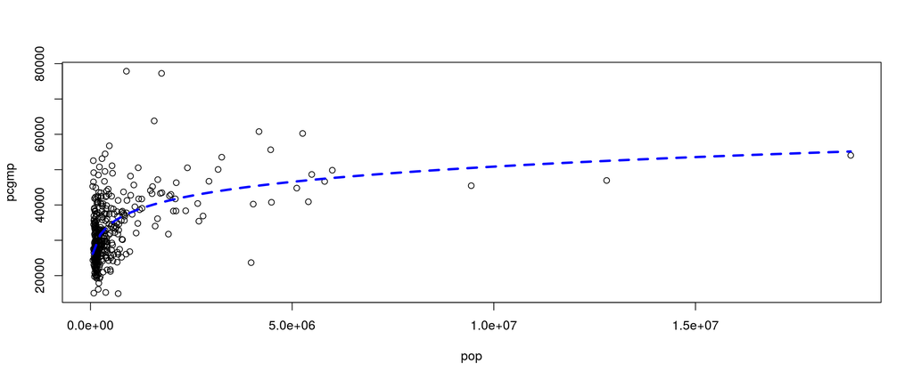

```r
plot(pcgmp ~ pop, data = gmp)
curve(fit1$par[1] * x^fit1$par[2], add = TRUE, lty = "dashed", col = "blue", lwd = 3)
```

## Summary

- Mathematical optimization methods: Curve-fitting, Gradient descent (and Newton’s method).
- Optimization using a R function: `optim()`.